# Поведение пользователей мобильного приложения, продающего продукты питания.

## Описание проекта

Вы работаете в стартапе, который продаёт продукты питания. Нужно разобраться, как ведут себя пользователи вашего мобильного приложения.

Изучите воронку продаж. Узнайте, как пользователи доходят до покупки. Сколько пользователей доходит до покупки, а сколько — «застревает» на предыдущих шагах? На каких именно?

После этого исследуйте результаты A/A/B-эксперимента. Дизайнеры захотели поменять шрифты во всём приложении, а менеджеры испугались, что пользователям будет непривычно. Договорились принять решение по результатам A/A/B-теста. Пользователей разбили на 3 группы: 2 контрольные со старыми шрифтами и одну экспериментальную — с новыми. Выясните, какой шрифт лучше.

## Описание данных

Каждая запись в логе — это действие пользователя, или событие.

- EventName — название события;
- DeviceIDHash **— уникальный идентификатор пользователя;
- EventTimestamp — время события;
- ExpId — номер эксперимента: 246 и 247 — контрольные группы, а 248 — экспериментальная.

## Оглавление:

- Шаг 1. Откройте файл с данными и изучите общую информацию
- Шаг 2. Подготовьте данные
- Шаг 3. Изучите и проверьте данные
- Шаг 4. Изучите воронку событий
- Шаг 5. Изучите результаты эксперимента
- Общий вывод

### Шаг 1. Откройте файл с данными и изучите общую информацию

```python
import pandas as pd
import numpy as np
import matplotlib.pyplot as plt
import seaborn as sns
import datetime as dt
from plotly import graph_objects as go
from scipy import stats as st
import math as mth
```

```python
event = pd.read_csv('/media/max/TOSHIBA EXT/YANDEX.Практикум/Файлы/logs_exp.csv', sep = '\t')
```

```python
event.info()
```

```
<class 'pandas.core.frame.DataFrame'>
RangeIndex: 244126 entries, 0 to 244125
Data columns (total 4 columns):
EventName         244126 non-null object
DeviceIDHash      244126 non-null int64
EventTimestamp    244126 non-null int64
ExpId             244126 non-null int64
dtypes: int64(3), object(1)
memory usage: 7.5+ MB
```

```python
event.head()
```

|  | EventName | DeviceIDHash | EventTimestamp | ExpId |
| --- | --- | --- | --- | --- |
| 0 | MainScreenAppear | 4575588528974610257 | 1564029816 | 246 |
| 1 | MainScreenAppear | 7416695313311560658 | 1564053102 | 246 |
| 2 | PaymentScreenSuccessful | 3518123091307005509 | 1564054127 | 248 |
| 3 | CartScreenAppear | 3518123091307005509 | 1564054127 | 248 |
| 4 | PaymentScreenSuccessful | 6217807653094995999 | 1564055322 | 248 |

### Вывод

Ознакомились с данными в файле: пропусков нет, колонку с датой нужно преобразовать в подходящий формат.

### Шаг 2. Подготовьте данные

#### 2.1 Заменим названия столбцов

```python
event.rename(columns={'EventName': 'event_name', 'DeviceIDHash': 'user_id','EventTimestamp':'event_time',\
                     'ExpId':'exp_id'}, inplace=True)
event.sample()
```

|  | event_name | user_id | event_time | exp_id |
| --- | --- | --- | --- | --- |
| 134317 | PaymentScreenSuccessful | 4998498972112971946 | 1564939073 | 246 |

#### 2.2 Проверим пропуски и типы данных.

```python
event['event_time'] = pd.to_datetime(event['event_time'], unit='s', origin='unix')
event.sample(3)
```

|  | event_name | user_id | event_time | exp_id |
| --- | --- | --- | --- | --- |
| 116925 | PaymentScreenSuccessful | 3521696259961091617 | 2019-08-04 09:40:36 | 248 |
| 82632 | OffersScreenAppear | 7820584748549110105 | 2019-08-03 09:03:38 | 248 |
| 69378 | OffersScreenAppear | 4933297437823212939 | 2019-08-02 18:22:07 | 246 |

```python
event.duplicated().sum()
```

```
413
```

```python
event = event.drop_duplicates()
event.info()
```

```
<class 'pandas.core.frame.DataFrame'>
Int64Index: 243713 entries, 0 to 244125
Data columns (total 4 columns):
event_name    243713 non-null object
user_id       243713 non-null int64
event_time    243713 non-null datetime64[ns]
exp_id        243713 non-null int64
dtypes: datetime64[ns](1), int64(2), object(1)
memory usage: 9.3+ MB
```

#### 2.3 Добавим столбец даты и времени, а также отдельный столбец дат

```python
event['event_time'].describe()
```

```
count                  243713
unique                 176654
top       2019-08-01 14:40:35
freq                        9
first     2019-07-25 04:43:36
last      2019-08-07 21:15:17
Name: event_time, dtype: object
```

```python
#event['date'] = event['event_time'].astype('datetime64[M]')
event['date'] = event['event_time'].dt.date
event.sample()
```

|  | event_name | user_id | event_time | exp_id | date |
| --- | --- | --- | --- | --- | --- |
| 9688 | PaymentScreenSuccessful | 5679515401100396705 | 2019-08-01 08:09:44 | 248 | 2019-08-01 |

### Вывод

Переименовали колонки.Обнаружили 413 дубликатов, удалили их.Преобразовали колонку с датой и временем в формат "datetime".Выделили в отдельную колонку информацию о дате события.

### Шаг 3. Изучите и проверьте данные

#### 3.1 Сколько всего событий в логе?

```python
event['event_name'].value_counts()
```

```
MainScreenAppear           119101
OffersScreenAppear          46808
CartScreenAppear            42668
PaymentScreenSuccessful     34118
Tutorial                     1018
Name: event_name, dtype: int64
```

В логе всего пять событий.

#### 3.2 Сколько всего пользователей в логе?

```python
event['user_id'].value_counts()
```

```
6304868067479728361    2307
197027893265565660     1998
4623191541214045580    1768
6932517045703054087    1439
1754140665440434215    1221
                       ...
3336727186673646149       1
1657967711232741323       1
425817683219936619        1
4089770943116790924       1
1083512226259476085       1
Name: user_id, Length: 7551, dtype: int64
```

Всего в логе 7551 пользователь.

#### 3.3 Сколько в среднем событий приходится на пользователя?

Данными за какой период вы располагаете? Найдите максимальную и минимальную дату. Постройте гистограмму по дате и времени. Можно ли быть уверенным, что у вас одинаково полные данные за весь период? Технически в логи новых дней по некоторым пользователям могут «доезжать» события из прошлого — это может «перекашивать данные». Определите, с какого момента данные полные и отбросьте более старые. Данными за какой период времени вы располагаете на самом деле?

```python
n_users= event['user_id'].nunique()
n_event = event['event_name'].count()
event_user_mean = n_event/n_users
event_user_mean
```

```
32.27559263673685
```

На одного пользователя приходится в среднем 32 события.

```python
event['event_time'].describe()
```

```
count                  243713
unique                 176654
top       2019-08-01 14:40:35
freq                        9
first     2019-07-25 04:43:36
last      2019-08-07 21:15:17
Name: event_time, dtype: object
```

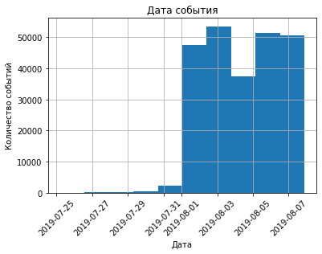

```python
event['event_time'].hist()
plt.title('Дата события')
plt.ylabel('Количество событий')
plt.xlabel('Дата')
plt.xticks(rotation=45)
plt.show()
```

Судя по гистограмме мы располагаем данными за одну неделю: с 01-08-2019 по 07-08-2019.

#### 3.4 Много ли событий и пользователей вы потеряли, отбросив старые данные?

```python
event_actual = event.query('event_time > "2019-07-31"')
event_actual.info()
```

```
<class 'pandas.core.frame.DataFrame'>
Int64Index: 242917 entries, 797 to 244125
Data columns (total 5 columns):
event_name    242917 non-null object
user_id       242917 non-null int64
event_time    242917 non-null datetime64[ns]
exp_id        242917 non-null int64
date          242917 non-null object
dtypes: datetime64[ns](1), int64(2), object(2)
memory usage: 11.1+ MB
```

```python
event_actual['event_name'].value_counts()
```

```
MainScreenAppear           118578
OffersScreenAppear          46707
CartScreenAppear            42560
PaymentScreenSuccessful     34058
Tutorial                     1014
Name: event_name, dtype: int64
```

```python
event_actual['user_id'].value_counts()
```

```
6304868067479728361    2307
197027893265565660     1998
4623191541214045580    1768
6932517045703054087    1439
1754140665440434215    1221
                       ...
8186183676377809366       1
1918918598819548986       1
8071397669512236988       1
1223708690315846789       1
1643533367516410257       1
Name: user_id, Length: 7542, dtype: int64
```

Мы потеряли порядка 800 записей, что составляет около 0.3% от перваночального количества.Также мы лишились 9 пользователей.В целом это не должно как-то существенно сказаться на результатах нашего исследования.

#### 3.5 Проверьте, что у вас есть пользователи из всех трёх экспериментальных групп.

```python
exg = event_actual.groupby('exp_id').agg({'user_id':'nunique'})
exg
```

| exp_id | user_id |
| --- | --- |
| 246 | 2485 |
| 247 | 2517 |
| 248 | 2540 |

У нас есть очень близкое количество пользователей всех трех групп.

### Вывод

Определили, что в логе 7551 пользователь и всего пять событий : MainScreenAppear,OffersScreenAppear,CartScreenAppear,PaymentScreenSuccessful,Tutorial . Определили,что мы располагаем данными за две недели.Определили максимальную дату - 2019-08-07 и минимальную дату - 2019-07-25. Построили гистограмму по дате и времени.Технически в логи новых дней по некоторым пользователям могут «доезжать» события из прошлого — это может «перекашивать данные» и судя по гистограмме мы располагаем данными за одну неделю: с 01-08-2019 по 07-08-2019. Определили ,что на одного пользователя приходится в среднем 32 события. Отбросив старые данные , мы потеряли порядка 800 записей, что составляет около 0.3% от перваночального количества.Также мы лишились 9 пользователей.В целом это не должно как-то существенно сказаться на результатах нашего исследования. Проверили , что у нас есть очень близкое количество пользователей всех трех экспериментальных групп после удаления старых данных.

### Шаг 4. Изучите воронку событий

#### 4.1 Посмотрите, какие события есть в логах, как часто они встречаются. Отсортируйте события по частоте.

```python
event_count = event_actual.groupby('event_name').agg({'user_id':'count'})

event_count.columns = ['event_count']
event_count.reset_index(level=0, inplace=True)
event_count = event_count.sort_values('event_count', ascending=False)

event_count
```

|  | event_name | event_count |
| --- | --- | --- |
| 1 | MainScreenAppear | 118578 |
| 2 | OffersScreenAppear | 46707 |
| 0 | CartScreenAppear | 42560 |
| 3 | PaymentScreenSuccessful | 34058 |
| 4 | Tutorial | 1014 |

```python
fig = go.Figure(go.Funnel(
    y = event_count['event_name'],
    x = event_count['event_count']
    ))
fig.update_layout(title="Частота событий")
fig.show()
```

[interactive chart not shown]

MainScreenAppear - самое часто встречаемое событие в логах. Tutorial - самое редкое событие.

#### 4.2 Посчитайте, сколько пользователей совершали каждое из этих событий. Отсортируйте события по числу пользователей. Посчитайте долю пользователей, которые хоть раз совершали событие.

**Общее количество пользователей**

```python
print(event_actual['user_id'].nunique())
```

```
7542
```

```python
event_user_count = event_actual.groupby('event_name').agg({'user_id':'nunique'})
event_user_count.columns = ['n_users']
event_user_count.reset_index(level=0, inplace=True)
event_user_count.loc[5] = ['total', 7542]
event_user_count = event_user_count.sort_values('n_users', ascending=False)
event_user_count
```

|  | event_name | n_users |
| --- | --- | --- |
| 5 | total | 7542 |
| 1 | MainScreenAppear | 7429 |
| 2 | OffersScreenAppear | 4606 |
| 0 | CartScreenAppear | 3742 |
| 3 | PaymentScreenSuccessful | 3542 |
| 4 | Tutorial | 845 |

```python
fig = go.Figure(go.Funnel(
    y = event_user_count['event_name'],
    x = event_user_count['n_users']
    ))
fig.update_layout(title="Количество пользователей, совершивших событие")
fig.show()
```

[interactive chart not shown]

**Событие совершили : MainScreenAppear - 98.5% пользователей, OffersScreenAppear - 61.1% пользователей, CartScreenAppear - 49.6% пользователей, PaymentScreenSuccessful - 47% пользователей, Tutorial - 11.2% пользователей**

#### 4.3 Предположите, в каком порядке происходят события. Все ли они выстраиваются в последовательную цепочку? Их не нужно учитывать при расчёте воронки.

```python
event_funnel = event_user_count.query('event_name != "Tutorial" and event_name != "total"')
event_funnel
```

|  | event_name | n_users |
| --- | --- | --- |
| 1 | MainScreenAppear | 7429 |
| 2 | OffersScreenAppear | 4606 |
| 0 | CartScreenAppear | 3742 |
| 3 | PaymentScreenSuccessful | 3542 |

```python
fig = go.Figure(go.Funnel(
    y = event_funnel['event_name'],
    x = event_funnel['n_users']
    ))
fig.update_layout(title="Последовательная воронка событий")
fig.show()
```

[interactive chart not shown]

MainScreenAppear, OffersScreenAppear,CartScreenAppear,PaymentScreenSuccessful- такой порядок событий представляется логичным. Потому что Tutorial можно открыть с любого шага и не стоит его ставить в воронку.

#### 4.4 По воронке событий посчитайте, какая доля пользователей проходит на следующий шаг воронки (от числа пользователей на предыдущем). То есть для последовательности событий A → B → C посчитайте отношение числа пользователей с событием B к количеству пользователей с событием A, а также отношение числа пользователей с событием C к количеству пользователей с событием B.

```python
msa = event_funnel.loc[1,'n_users']
osa = event_funnel.loc[2,'n_users']
csa = event_funnel.loc[0,'n_users']
pss = event_funnel.loc[3,'n_users']
print('Доля пользователей на MainScreenAppear: 98.5%')
print('Доля пользователей,переходящих с MainScreenAppear на OffersScreenAppear: {:.1%}'.format(osa/msa))
print('Доля пользователей,переходящих с OffersScreenAppear на CartScreenAppear: {:.1%}'.format(csa/osa))
print('Доля пользователей,переходящих с CartScreenAppear на PaymentScreenSuccessful: {:.1%}'.format(pss/csa))
```

```
Доля пользователей на MainScreenAppear: 98.5%
Доля пользователей,переходящих с MainScreenAppear на OffersScreenAppear: 62.0%
Доля пользователей,переходящих с OffersScreenAppear на CartScreenAppear: 81.2%
Доля пользователей,переходящих с CartScreenAppear на PaymentScreenSuccessful: 94.7%
```

MainScreenAppear -98.5%, OffersScreenAppear - 62%,CartScreenAppear- 81.2%,PaymentScreenSuccessful -94.7%

#### 4.5 На каком шаге теряете больше всего пользователей?

На втором шаге теряется больше всего пользователей, то есть при переходе с главной страницы на OffersScreenAppear.

#### 4.6 Какая доля пользователей доходит от первого события до оплаты?

```python
print('Доля пользователей,дошедших с MainScreenAppear до PaymentScreenSuccessful: {:.1%}'.format(pss/msa))
```

```
Доля пользователей,дошедших с MainScreenAppear до PaymentScreenSuccessful: 47.7%
```

От первого события до оплаты доходит 47.7% пользователей.

### Шаг 5. Изучите результаты эксперимента

#### 5.1 Сколько пользователей в каждой экспериментальной группе?

```python
exg
```

| exp_id | user_id |
| --- | --- |
| 246 | 2485 |
| 247 | 2517 |
| 248 | 2540 |

```python
exg.columns = ['total']
exg.reset_index(level=0, inplace=True)
```

В группе 246 - 2485 пользоваелей, в группе 247 - 2517 пользователей, в группе 248 - 2540 пользователей.

#### 5.2 Есть 2 контрольные группы для А/А-эксперимента, чтобы проверить корректность всех механизмов и расчётов. Проверьте, находят ли статистические критерии разницу между выборками 246 и 247. Выберите самое популярное событие. Посчитайте число пользователей, совершивших это событие в каждой из контрольных групп. Посчитайте долю пользователей, совершивших это событие. Проверьте, будет ли отличие между группами статистически достоверным. Проделайте то же самое для всех других событий (удобно обернуть проверку в отдельную функцию). Можно ли сказать, что разбиение на группы работает корректно?

```python
print(exg['total'][1]/exg['total'][0])
```

```
1.0128772635814889
```

Один из критериев успешности А\А теста - количество пользователей, попавших в различные группы, отличается не более, чем на 0.5%. В нашем случае разница в 1.2%, что уже говорит о несоответсвии групп с одной стороны.

```python
def part(data,alpha):
    data = data.groupby('exp_id').agg({'user_id':'nunique'})
    data.rename(columns={'user_id':'success'}, inplace=True)
    data = pd.merge(data,exg,on='exp_id')
    data['part'] = (data['success']/data['total'])*100



    successes = data['success'].values
    trials = data['total'].values

# пропорция успехов в первой группе:
    p1 = successes[0]/trials[0]

# пропорция успехов во второй группе:
    p2 = successes[1]/trials[1]

# пропорция успехов в комбинированном датасете:
    p_combined = (successes[0] + successes[1]) / (trials[0] + trials[1])

# разница пропорций в датасетах
    difference = p1 - p2


# считаем статистику в ст.отклонениях стандартного нормального распределения
    z_value = difference / mth.sqrt(p_combined * (1 - p_combined) * (1/trials[0] + 1/trials[1]))

# задаем стандартное нормальное распределение (среднее 0, ст.отклонение 1)
    distr = st.norm(0, 1)


# считаем статистику в ст.отклонениях стандартного нормального распределения
    z_value = difference / mth.sqrt(p_combined * (1 - p_combined) * (1/trials[0] + 1/trials[1]))

# задаем стандартное нормальное распределение (среднее 0, ст.отклонение 1)
    distr = st.norm(0, 1)

    p_value = (1 - distr.cdf(abs(z_value))) * 2

    print('p-значение: ', p_value)

    if (p_value < alpha):
        print("Отвергаем нулевую гипотезу: между группами есть значимая разница")
    else:
        print("Не получилось отвергнуть нулевую гипотезу, нет оснований считать конверсии групп разными")
    display(data)
```

```python
msap = event_actual.query('event_name == "MainScreenAppear" and exp_id != "248"')
part(msap,0.01)
```

```
p-значение:  0.5868776836512959
Не получилось отвергнуть нулевую гипотезу, нет оснований считать конверсии групп разными
```

|  | exp_id | success | total | part |
| --- | --- | --- | --- | --- |
| 0 | 246 | 2452 | 2485 | 98.672032 |
| 1 | 247 | 2479 | 2517 | 98.490266 |

```python
osap = event_actual.query('event_name == "OffersScreenAppear" and exp_id != "248"')

part(osap,0.01)
```

```
p-значение:  0.2743505991932964
Не получилось отвергнуть нулевую гипотезу, нет оснований считать конверсии групп разными
```

|  | exp_id | success | total | part |
| --- | --- | --- | --- | --- |
| 0 | 246 | 1544 | 2485 | 62.132797 |
| 1 | 247 | 1526 | 2517 | 60.627731 |

```python
csap = event_actual.query('event_name == "CartScreenAppear" and exp_id != "248"')

part(csap,0.01)
```

```
p-значение:  0.21306131796590932
Не получилось отвергнуть нулевую гипотезу, нет оснований считать конверсии групп разными
```

|  | exp_id | success | total | part |
| --- | --- | --- | --- | --- |
| 0 | 246 | 1267 | 2485 | 50.985915 |
| 1 | 247 | 1239 | 2517 | 49.225268 |

```python
pssp = event_actual.query('event_name == "PaymentScreenSuccessful" and exp_id != "248"')

part(pssp,0.01)
```

```
p-значение:  0.11210845100173072
Не получилось отвергнуть нулевую гипотезу, нет оснований считать конверсии групп разными
```

|  | exp_id | success | total | part |
| --- | --- | --- | --- | --- |
| 0 | 246 | 1200 | 2485 | 48.289738 |
| 1 | 247 | 1159 | 2517 | 46.046881 |

**Посчитали число пользователей, совершивших каждое событие в каждой из контрольных групп(246,247). Посчитали долю пользователей, совершивших это событие. Проверили нулевую гипотезу - конверсия переходов группы 246 и 247 равны. Установили уровень значимости в 0.01. По каждому событию сравнили конверсии двух групп и во всех случаях не получилось отвергнуть нулевую гипотезу, нет оснований считать конверсии групп разными.А значит разбиение на группы работает корректно.**

#### 5.3 Аналогично поступите с группой с изменённым шрифтом. Сравните результаты с каждой из контрольных групп в отдельности по каждому событию. Сравните результаты с объединённой контрольной группой. Какие выводы из эксперимента можно сделать?

##### Для групп 247 и 248

```python
msap_78 = event_actual.query('event_name == "MainScreenAppear" and exp_id != "246"')
part(msap_78,0.01)
```

```
p-значение:  0.681958382603927
Не получилось отвергнуть нулевую гипотезу, нет оснований считать конверсии групп разными
```

|  | exp_id | success | total | part |
| --- | --- | --- | --- | --- |
| 0 | 247 | 2479 | 2517 | 98.490266 |
| 1 | 248 | 2498 | 2540 | 98.346457 |

```python
osap_78 = event_actual.query('event_name == "OffersScreenAppear" and exp_id != "246"')

part(osap_78,0.01)
```

```
p-значение:  0.9100517394454506
Не получилось отвергнуть нулевую гипотезу, нет оснований считать конверсии групп разными
```

|  | exp_id | success | total | part |
| --- | --- | --- | --- | --- |
| 0 | 247 | 1526 | 2517 | 60.627731 |
| 1 | 248 | 1536 | 2540 | 60.472441 |

```python
csap_78 = event_actual.query('event_name == "CartScreenAppear" and exp_id != "246"')

part(csap_78,0.01)
```

```
p-значение:  0.6883799508125226
Не получилось отвергнуть нулевую гипотезу, нет оснований считать конверсии групп разными
```

|  | exp_id | success | total | part |
| --- | --- | --- | --- | --- |
| 0 | 247 | 1239 | 2517 | 49.225268 |
| 1 | 248 | 1236 | 2540 | 48.661417 |

```python
pssp_78 = event_actual.query('event_name == "PaymentScreenSuccessful" and exp_id != "246"')

part(pssp_78,0.01)
```

```
p-значение:  0.7065894728746211
Не получилось отвергнуть нулевую гипотезу, нет оснований считать конверсии групп разными
```

|  | exp_id | success | total | part |
| --- | --- | --- | --- | --- |
| 0 | 247 | 1159 | 2517 | 46.046881 |
| 1 | 248 | 1183 | 2540 | 46.574803 |

##### Для групп 246 и 248

```python
msap_68 = event_actual.query('event_name == "MainScreenAppear" and exp_id != "247"')
part(msap_68,0.01)
```

```
p-значение:  0.341286386031747
Не получилось отвергнуть нулевую гипотезу, нет оснований считать конверсии групп разными
```

|  | exp_id | success | total | part |
| --- | --- | --- | --- | --- |
| 0 | 246 | 2452 | 2485 | 98.672032 |
| 1 | 248 | 2498 | 2540 | 98.346457 |

```python
osap_68 = event_actual.query('event_name == "OffersScreenAppear" and exp_id != "247"')

part(osap_68,0.01)
```

```
p-значение:  0.22699680075034445
Не получилось отвергнуть нулевую гипотезу, нет оснований считать конверсии групп разными
```

|  | exp_id | success | total | part |
| --- | --- | --- | --- | --- |
| 0 | 246 | 1544 | 2485 | 62.132797 |
| 1 | 248 | 1536 | 2540 | 60.472441 |

```python
csap_68 = event_actual.query('event_name == "CartScreenAppear" and exp_id != "247"')

part(csap_68,0.01)
```

```
p-значение:  0.09941721664866177
Не получилось отвергнуть нулевую гипотезу, нет оснований считать конверсии групп разными
```

|  | exp_id | success | total | part |
| --- | --- | --- | --- | --- |
| 0 | 246 | 1267 | 2485 | 50.985915 |
| 1 | 248 | 1236 | 2540 | 48.661417 |

```python
pssp_68 = event_actual.query('event_name == "PaymentScreenSuccessful" and exp_id != "247"')

part(pssp_68,0.01)
```

```
p-значение:  0.22352231840506898
Не получилось отвергнуть нулевую гипотезу, нет оснований считать конверсии групп разными
```

|  | exp_id | success | total | part |
| --- | --- | --- | --- | --- |
| 0 | 246 | 1200 | 2485 | 48.289738 |
| 1 | 248 | 1183 | 2540 | 46.574803 |

Посчитали число пользователей, совершивших каждое событие в группе 248 и сравнили с данными из групп 246,247. Посчитали долю пользователей, совершивших это событие. Проверили нулевую гипотезу - конверсия переходов группы 248 и 247 равны. Установили уровень значимости в 0.01, так как мы проводим множество проверок и есть риск возникновения ложного результата . По каждому событию сравнили конверсии двух групп и во всех случаях не получилось отвергнуть нулевую гипотезу, нет оснований считать конверсии групп разными.Проверили нулевую гипотезу - конверсия переходов группы 248 и 246 равны.По каждому событию сравнили конверсии двух групп и во всех случаях не получилось отвергнуть нулевую гипотезу, нет оснований считать группы разными.

##### Для группы 248 и объединенной группы

```python
def combpart(data, alpha):

    data = data.groupby('exp_id').agg({'user_id':'nunique'})
    data.rename(columns={'user_id':'success'}, inplace=True)
    data = pd.merge(data,exg,on='exp_id')
#объеденим данные по двум группам 246 и 247 в одну 493
    n2 =  data['success'][0] + data['success'][1]
    n3 = data['total'][0] + data['total'][1]
    data.loc[3] = {'exp_id': 493, 'success': n2, 'total': n3}
    data.drop([0,1], inplace=True)
    data['part'] = (data['success']/data['total'])*100


    successes = data['success'].values
    trials = data['total'].values

# пропорция успехов в первой группе:
    p1 = successes[0]/trials[0]

# пропорция успехов во второй группе:
    p2 = successes[1]/trials[1]

# пропорция успехов в комбинированном датасете:
    p_combined = (successes[0] + successes[1]) / (trials[0] + trials[1])

# разница пропорций в датасетах
    difference = p1 - p2


# считаем статистику в ст.отклонениях стандартного нормального распределения
    z_value = difference / mth.sqrt(p_combined * (1 - p_combined) * (1/trials[0] + 1/trials[1]))

# задаем стандартное нормальное распределение (среднее 0, ст.отклонение 1)
    distr = st.norm(0, 1)


# считаем статистику в ст.отклонениях стандартного нормального распределения
    z_value = difference / mth.sqrt(p_combined * (1 - p_combined) * (1/trials[0] + 1/trials[1]))

# задаем стандартное нормальное распределение (среднее 0, ст.отклонение 1)
    distr = st.norm(0, 1)

    p_value = (1 - distr.cdf(abs(z_value))) * 2

    print('p-значение: ', p_value)

    if (p_value < alpha):
        print("Отвергаем нулевую гипотезу: между группами есть значимая разница")
    else:
        print("Не получилось отвергнуть нулевую гипотезу, нет оснований считать группы разными")
    display(data)
```

```python
msap_83 = event_actual.query('event_name == "MainScreenAppear"')
combpart(msap_83,0.01)
```

```
p-значение:  0.42897263461182167
Не получилось отвергнуть нулевую гипотезу, нет оснований считать группы разными
```

|  | exp_id | success | total | part |
| --- | --- | --- | --- | --- |
| 2 | 248 | 2498 | 2540 | 98.346457 |
| 3 | 493 | 4931 | 5002 | 98.580568 |

```python
osap_83 = event_actual.query('event_name == "OffersScreenAppear"')

combpart(osap_83,0.01)
```

```
p-значение:  0.4471809415681398
Не получилось отвергнуть нулевую гипотезу, нет оснований считать группы разными
```

|  | exp_id | success | total | part |
| --- | --- | --- | --- | --- |
| 2 | 248 | 1536 | 2540 | 60.472441 |
| 3 | 493 | 3070 | 5002 | 61.375450 |

```python
csap_83 = event_actual.query('event_name == "CartScreenAppear"')

combpart(csap_83,0.01)
```

```
p-значение:  0.23764471031415635
Не получилось отвергнуть нулевую гипотезу, нет оснований считать группы разными
```

|  | exp_id | success | total | part |
| --- | --- | --- | --- | --- |
| 2 | 248 | 1236 | 2540 | 48.661417 |
| 3 | 493 | 2506 | 5002 | 50.099960 |

```python
pssp_83 = event_actual.query('event_name == "PaymentScreenSuccessful"')

combpart(pssp_83,0.01)
```

```
p-значение:  0.629668311887492
Не получилось отвергнуть нулевую гипотезу, нет оснований считать группы разными
```

|  | exp_id | success | total | part |
| --- | --- | --- | --- | --- |
| 2 | 248 | 1183 | 2540 | 46.574803 |
| 3 | 493 | 2359 | 5002 | 47.161136 |

Посчитали число пользователей, совершивших каждое событие в группе 248 и сравнили с объединенными данными из групп 246,247. Посчитали долю пользователей, совершивших это событие. Проверили нулевую гипотезу - конверсия переходов группы 248 и 493(объединенная таблица) равны. Установили уровень значимости в 0.01, так как мы проводим множество проверок и есть риск возникновения ложного результата . По каждому событию сравнили конверсии двух групп и во всех случаях не получилось отвергнуть нулевую гипотезу, нет оснований считать конверсии групп разными.

#### 5.4 Какой уровень значимости вы выбрали при проверке статистических гипотез выше? Посчитайте, сколько проверок статистических гипотез вы сделали. При уровне значимости 0.1 каждый десятый раз можно получать ложный результат. Какой уровень значимости стоит применить?

**Было проведено 16 проверок статистических гипотез. Именно из-за возможности получения ложного результата при проведении большого количества проверок критический уровень статистической значимости был взят в 0.01, а не 0.05(максимально допустимый)**

### Вывод

Определили, что в группе 246 - 2485 пользоваелей, в группе 247 - 2517 пользователей, в группе 248 - 2540 пользователей. Проверили, находят ли статистические критерии разницу между выборками 246 и 247. Посчитали число пользователей, совершивших каждое событие в каждой из контрольных групп. Посчитали долю пользователей, совершивших это событие. Проверили, будет ли отличие между группами статистически достоверным. Один из критериев успешности А\А теста - количество пользователей, попавших в различные группы, отличается не более, чем на 0.5%. В нашем случае разница в 1.2%, что уже говорит о несоответсвии групп 246 и 247 с одной стороны.

Посчитали число пользователей, совершивших каждое событие в каждой из контрольных групп(246,247). Посчитали долю пользователей, совершивших это событие.

Установили уровень значимости в 0.01, так как мы проводим множество проверок и есть риск возникновения ложного результата .

Проверили нулевую гипотезу - конверсия переходов группы 246 и 247 равны. По каждому событию сравнили конверсии двух групп и во всех случаях не получилось отвергнуть нулевую гипотезу, нет оснований считать конверсии групп разными.А значит разбиение на группы работает корректно.

Посчитали число пользователей, совершивших каждое событие в группе 248 и сравнили с данными из групп 246,247. Посчитали долю пользователей, совершивших это событие. Проверили нулевую гипотезу - конверсия переходов группы 248 и 247 равны. По каждому событию сравнили конверсии двух групп и во всех случаях не получилось отвергнуть нулевую гипотезу, нет оснований считать конверсии групп разными.

Проверили нулевую гипотезу - конверсия переходов группы 248 и 246 равны.По каждому событию сравнили конверсии двух групп и во всех случаях не получилось отвергнуть нулевую гипотезу, нет оснований считать группы разными.

Посчитали число пользователей, совершивших каждое событие в группе 248 и сравнили с объединенными данными из групп 246,247. Посчитали долю пользователей, совершивших это событие. Проверили нулевую гипотезу - конверсия переходов группы 248 и 493(объединенная таблица) равны. По каждому событию сравнили конверсии двух групп и во всех случаях не получилось отвергнуть нулевую гипотезу, нет оснований считать конверсии групп разными.

**Было проведено 16 проверок статистических гипотез. Именно из-за возможности получения ложного результата при проведении большого количества проверок критический уровень статистической значимости был взят в 0.01, а не 0.05(максимально допустимый)**

### Общий вывод

Ознакомились с данными в файле: пропусков нет.Переименовали колонки.Обнаружили 413 дубликатов, удалили их.Преобразовали колонку с датой и временем в формат "datetime".Выделили в отдельную колонку информацию о дате события.

Определили, что в логе 7551 пользователь и всего пять событий : MainScreenAppear,OffersScreenAppear,CartScreenAppear,PaymentScreenSuccessful,Tutorial . Определили,что мы располагаем данными за две недели.Определили максимальную дату - 2019-08-07 и минимальную дату - 2019-07-25. Построили гистограмму по дате и времени.Технически в логи новых дней по некоторым пользователям могут «доезжать» события из прошлого — это может «перекашивать данные» и судя по гистограмме мы располагаем данными за одну неделю: с 01-08-2019 по 07-08-2019. Определили ,что на одного пользователя приходится в среднем 32 события. Отбросив старые данные , мы потеряли порядка 800 записей, что составляет около 0.3% от перваночального количества.Также мы лишились 9 пользователей.В целом это не должно как-то существенно сказаться на результатах нашего исследования. Проверили , что у нас есть очень близкое количество пользователей всех трех экспериментальных групп после удаления старых данных.

Определили, что в группе 246 - 2485 пользоваелей, в группе 247 - 2517 пользователей, в группе 248 - 2540 пользователей. Проверили, находят ли статистические критерии разницу между выборками 246 и 247. Посчитали число пользователей, совершивших каждое событие в каждой из контрольных групп. Посчитали долю пользователей, совершивших это событие. Проверили, будет ли отличие между группами статистически достоверным. Один из критериев успешности А\А теста - количество пользователей, попавших в различные группы, отличается не более, чем на 0.5%. В нашем случае разница в 1.2%, что уже говорит о несоответсвии групп 246 и 247 с одной стороны.

Посчитали число пользователей, совершивших каждое событие в каждой из контрольных групп(246,247). Посчитали долю пользователей, совершивших это событие.А значит разбиение на группы работает корректно.

Установили уровень значимости в 0.01, так как мы проводим множество проверок и есть риск возникновения ложного результата .

Проверили нулевую гипотезу - конверсия переходов группы 246 и 247 равны. По каждому событию сравнили конверсии двух групп и во всех случаях не получилось отвергнуть нулевую гипотезу, нет оснований считать коверсии групп разными.

Посчитали число пользователей, совершивших каждое событие в группе 248 и сравнили с данными из групп 246,247. Посчитали долю пользователей, совершивших это событие. Проверили нулевую гипотезу - конверсия переходов группы 248 и 247 равны. По каждому событию сравнили конверсии двух групп и во всех случаях не получилось отвергнуть нулевую гипотезу, нет оснований считать конверсии групп разными.

Проверили нулевую гипотезу - конверсия переходов группы 248 и 246 равны.По каждому событию сравнили конверсии двух групп и во всех случаях не получилось отвергнуть нулевую гипотезу, нет оснований считать группы разными.

Посчитали число пользователей, совершивших каждое событие в группе 248 и сравнили с объединенными данными из групп 246,247. Посчитали долю пользователей, совершивших это событие. Проверили нулевую гипотезу - конверсия переходов группы 248 и 493(объединенная таблица) равны. По каждому событию сравнили конверсии двух групп и во всех случаях не получилось отвергнуть нулевую гипотезу, нет оснований считать конверсии групп разными.

** Было проведено 16 проверок статистических гипотез. Именно из-за возможности получения ложного результата при проведении большого количества проверок критический уровень статистической значимости был взят в 0.01, а не 0.05(максимально допустимый)

Исходя из проведенных тестов можно предположить,что изменение шрифта во всём приложении не повлечет потери конверсии от покупателей.